# Logistic Regression Lab

# Sample

```r
loan <- read.csv("lending_club_cleaned.csv")
summary(loan)
```

```
##    good                     purpose           fico            dti
##  bad : 6371   debt_consolidation:25253   Min.   :612.0   Min.   : 0.00
##  good:36164   other             : 5160   1st Qu.:687.0   1st Qu.: 8.20
##               major_purchase    : 3926   Median :712.0   Median :13.47
##               home_improvement  : 3625   Mean   :715.1   Mean   :13.37
##               small_business    : 1992   3rd Qu.:742.0   3rd Qu.:18.68
##               vacation_wedding  : 1404   Max.   :827.0   Max.   :29.99
##               (Other)           : 1175
##    loan_amnt         income
##  Min.   :  500   Min.   :   4800
##  1st Qu.: 5200   1st Qu.:  44995
##  Median : 9700   Median :  63000
##  Mean   :11090   Mean   :  75186
##  3rd Qu.:15000   3rd Qu.:  90000
##  Max.   :35000   Max.   :6000000
##                  NA's   :18758
```

```r
logit1 <- glm(good ~ fico, data = loan, family = "binomial")
summary(logit1)
```

```
##
## Call:
## glm(formula = good ~ fico, family = "binomial", data = loan)
##
## Deviance Residuals:
##     Min       1Q   Median       3Q      Max
## -2.5172   0.4078   0.5306   0.6294   0.9622
##
## Coefficients:
##              Estimate Std. Error z value Pr(>|z|)
## (Intercept) -7.033068   0.296922  -23.69   <2e-16 ***
## fico         0.012358   0.000421   29.35   <2e-16 ***
## ---
## Signif. codes:  0 '***' 0.001 '**' 0.01 '*' 0.05 '.' 0.1 ' ' 1
##
## (Dispersion parameter for binomial family taken to be 1)
##
##     Null deviance: 35928  on 42534  degrees of freedom
## Residual deviance: 34985  on 42533  degrees of freedom
## AIC: 34989
##
## Number of Fisher Scoring iterations: 5
```

```r
#odds ratio interpretation
exp(coef(logit1))
```

```
##  (Intercept)         fico
## 0.0008822209 1.0124345145
```

```r
#probability interpretation
test <- data.frame(fico=c(700,750))
test$pred <- predict(logit1,test, type="response")
test
```

```
##   fico      pred
## 1  700 0.8344391
## 2  750 0.9033761
```

```r
logit2 <- glm(good ~ fico + loan_amnt, data = loan, family = "binomial")
summary(logit2)
```

```
##
## Call:
## glm(formula = good ~ fico + loan_amnt, family = "binomial", data = loan)
##
## Deviance Residuals:
##     Min       1Q   Median       3Q      Max
## -2.6261   0.4011   0.5256   0.6261   0.9423
##
## Coefficients:
##               Estimate Std. Error z value Pr(>|z|)
## (Intercept) -7.367e+00  3.007e-01  -24.50   <2e-16 ***
## fico         1.319e-02  4.306e-04   30.62   <2e-16 ***
## loan_amnt   -2.229e-05  1.815e-06  -12.28   <2e-16 ***
## ---
## Signif. codes:  0 '***' 0.001 '**' 0.01 '*' 0.05 '.' 0.1 ' ' 1
##
## (Dispersion parameter for binomial family taken to be 1)
##
##     Null deviance: 35928  on 42534  degrees of freedom
## Residual deviance: 34838  on 42532  degrees of freedom
## AIC: 34844
##
## Number of Fisher Scoring iterations: 5
```

```r
#odds ratio interpretation
exp(coef(logit2))
```

```
##  (Intercept)         fico    loan_amnt
## 0.0006316636 1.0132732517 0.9999777084
```

```r
logit3 <- glm(good ~ fico + loan_amnt + purpose, data = loan, family = "binomial")
summary(logit3)
```

```
##
## Call:
## glm(formula = good ~ fico + loan_amnt + purpose, family = "binomial",
##     data = loan)
##
## Deviance Residuals:
##     Min       1Q   Median       3Q      Max
## -2.6865   0.3882   0.5136   0.6193   1.2974
##
## Coefficients:
##                           Estimate Std. Error z value Pr(>|z|)
## (Intercept)             -7.508e+00  3.030e-01 -24.780  < 2e-16 ***
## fico                     1.356e-02  4.361e-04  31.093  < 2e-16 ***
## loan_amnt               -2.311e-05  1.898e-06 -12.177  < 2e-16 ***
## purposeeducational      -5.552e-01  1.233e-01  -4.503 6.69e-06 ***
## purposehome_improvement -1.404e-01  5.245e-02  -2.677 0.007418 **
## purposemajor_purchase    5.918e-02  5.651e-02   1.047 0.295023
## purposemedical          -3.498e-01  1.005e-01  -3.481 0.000499 ***
## purposeother            -3.347e-01  4.276e-02  -7.827 4.99e-15 ***
## purposesmall_business   -9.380e-01  5.472e-02 -17.140  < 2e-16 ***
## purposevacation_wedding  1.160e-01  8.625e-02   1.345 0.178738
## ---
## Signif. codes:  0 '***' 0.001 '**' 0.01 '*' 0.05 '.' 0.1 ' ' 1
##
## (Dispersion parameter for binomial family taken to be 1)
##
##     Null deviance: 35928  on 42534  degrees of freedom
## Residual deviance: 34502  on 42525  degrees of freedom
## AIC: 34522
##
## Number of Fisher Scoring iterations: 5
```

```r
#odds ratio interpretation
round(exp(coef(logit3)),3)
```

```
##             (Intercept)                    fico               loan_amnt
##                   0.001                   1.014                   1.000
##      purposeeducational purposehome_improvement   purposemajor_purchase
##                   0.574                   0.869                   1.061
##          purposemedical            purposeother   purposesmall_business
##                   0.705                   0.716                   0.391
## purposevacation_wedding
##                   1.123
```

```r
#missing values
logit4 <- glm(good ~ fico + loan_amnt + income + purpose, data = loan, family = "binomial")
summary(logit4)
```

```
##
## Call:
## glm(formula = good ~ fico + loan_amnt + income + purpose, family = "binomial",
##     data = loan)
##
## Deviance Residuals:
##     Min       1Q   Median       3Q      Max
## -3.3659   0.3840   0.5224   0.6320   1.2589
##
## Coefficients:
##                           Estimate Std. Error z value Pr(>|z|)
## (Intercept)             -7.482e+00  4.119e-01 -18.165  < 2e-16 ***
## fico                     1.303e-02  5.906e-04  22.061  < 2e-16 ***
## loan_amnt               -3.663e-05  2.580e-06 -14.200  < 2e-16 ***
## income                   7.203e-06  5.426e-07  13.275  < 2e-16 ***
## purposeeducational      -5.076e-01  2.309e-01  -2.198   0.0279 *
## purposehome_improvement -1.077e-01  7.108e-02  -1.515   0.1298
## purposemajor_purchase    1.388e-02  7.689e-02   0.180   0.8568
## purposemedical          -2.678e-01  1.426e-01  -1.878   0.0604 .
## purposeother            -2.988e-01  6.034e-02  -4.952 7.34e-07 ***
## purposesmall_business   -9.158e-01  7.016e-02 -13.052  < 2e-16 ***
## purposevacation_wedding  1.114e-01  1.126e-01   0.989   0.3226
## ---
## Signif. codes:  0 '***' 0.001 '**' 0.01 '*' 0.05 '.' 0.1 ' ' 1
##
## (Dispersion parameter for binomial family taken to be 1)
##
##     Null deviance: 20592  on 23776  degrees of freedom
## Residual deviance: 19677  on 23766  degrees of freedom
##   (18758 observations deleted due to missingness)
## AIC: 19699
##
## Number of Fisher Scoring iterations: 5
```

```r
set.seed(364)
sample <- sample(nrow(loan),floor(nrow(loan)*0.8))
train <- loan[sample,]
test <- loan[-sample,]

logit4 <- glm(good ~ fico + dti+ loan_amnt + purpose, data = train, family = "binomial")
test$pred <- predict(logit4, test, type="response")

test$good_pred <- ifelse(test$pred > 0.80, "good", "bad")
table(test$good_pred, test$good)
```

```
##
##         bad good
##   bad   427 1265
##   good  818 5997
```

```r
library(pROC)
```

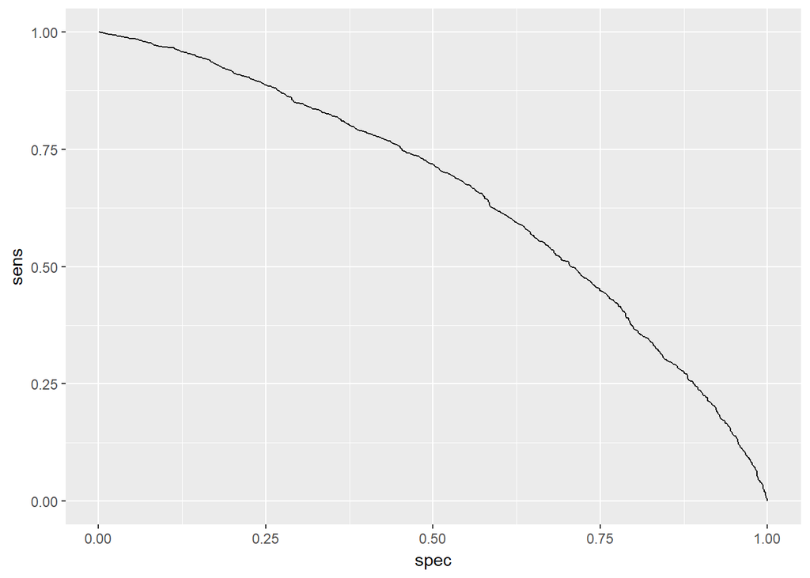

```r
roc <- roc(test$good,test$pred) #creates an object with all sorts of diagnostics including sensitivities and specificities

test$sens <- roc$sensitivities[2:8508] #include sensitivities in test data
test$spec <- roc$specificities[2:8508]

ggplot(test, aes(x=spec, y=sens)) + geom_line()
```

# Exercises

```r
titanic <- read.csv("titanic_train.csv")
```

```r
#What are the odds of surviving the shipwreck?
summary(titanic)
```

```
##   PassengerId       Survived          Pclass
##  Min.   :  1.0   Min.   :0.0000   Min.   :1.000
##  1st Qu.:223.5   1st Qu.:0.0000   1st Qu.:2.000
##  Median :446.0   Median :0.0000   Median :3.000
##  Mean   :446.0   Mean   :0.3838   Mean   :2.309
##  3rd Qu.:668.5   3rd Qu.:1.0000   3rd Qu.:3.000
##  Max.   :891.0   Max.   :1.0000   Max.   :3.000
##
##                                     Name         Sex           Age
##  Abbing, Mr. Anthony                  :  1   female:314   Min.   : 0.42
##  Abbott, Mr. Rossmore Edward          :  1   male  :577   1st Qu.:20.12
##  Abbott, Mrs. Stanton (Rosa Hunt)     :  1                Median :28.00
##  Abelson, Mr. Samuel                  :  1                Mean   :29.70
##  Abelson, Mrs. Samuel (Hannah Wizosky):  1                3rd Qu.:38.00
##  Adahl, Mr. Mauritz Nils Martin       :  1                Max.   :80.00
##  (Other)                              :885                NA's   :177
##      SibSp           Parch             Ticket         Fare
##  Min.   :0.000   Min.   :0.0000   1601    :  7   Min.   :  0.00
##  1st Qu.:0.000   1st Qu.:0.0000   347082  :  7   1st Qu.:  7.91
##  Median :0.000   Median :0.0000   CA. 2343:  7   Median : 14.45
##  Mean   :0.523   Mean   :0.3816   3101295 :  6   Mean   : 32.20
##  3rd Qu.:1.000   3rd Qu.:0.0000   347088  :  6   3rd Qu.: 31.00
##  Max.   :8.000   Max.   :6.0000   CA 2144 :  6   Max.   :512.33
##                                   (Other) :852
##          Cabin     Embarked
##             :687    :  2
##  B96 B98    :  4   C:168
##  C23 C25 C27:  4   Q: 77
##  G6         :  4   S:644
##  C22 C26    :  3
##  D          :  3
##  (Other)    :186
```

```r
logit1 <- glm(Survived ~ Sex, data = titanic, family = "binomial")
summary(logit1)
```

```
##
## Call:
## glm(formula = Survived ~ Sex, family = "binomial", data = titanic)
##
## Deviance Residuals:
##     Min       1Q   Median       3Q      Max
## -1.6462  -0.6471  -0.6471   0.7725   1.8256
##
## Coefficients:
##             Estimate Std. Error z value Pr(>|z|)
## (Intercept)   1.0566     0.1290   8.191 2.58e-16 ***
## Sexmale      -2.5137     0.1672 -15.036  < 2e-16 ***
## ---
## Signif. codes:  0 '***' 0.001 '**' 0.01 '*' 0.05 '.' 0.1 ' ' 1
##
## (Dispersion parameter for binomial family taken to be 1)
##
##     Null deviance: 1186.7  on 890  degrees of freedom
## Residual deviance:  917.8  on 889  degrees of freedom
## AIC: 921.8
##
## Number of Fisher Scoring iterations: 4
```

```r
exp(coef(summary(logit1)))
```

```
##               Estimate Std. Error      z value Pr(>|z|)
## (Intercept) 2.87654321   1.137675 3.610051e+03        1
## Sexmale     0.08096732   1.181965 2.950540e-07        1
```

Using the logit model, estimate how much lower are the odds of survival for men relative to women? 92% lower

```r
logit2 <- glm(Survived ~ Sex+Age, data = titanic, family = "binomial")
summary(logit2)
```

```
##
## Call:
## glm(formula = Survived ~ Sex + Age, family = "binomial", data = titanic)
##
## Deviance Residuals:
##     Min       1Q   Median       3Q      Max
## -1.7405  -0.6885  -0.6558   0.7533   1.8989
##
## Coefficients:
##              Estimate Std. Error z value Pr(>|z|)
## (Intercept)  1.277273   0.230169   5.549 2.87e-08 ***
## Sexmale     -2.465920   0.185384 -13.302  < 2e-16 ***
## Age         -0.005426   0.006310  -0.860     0.39
## ---
## Signif. codes:  0 '***' 0.001 '**' 0.01 '*' 0.05 '.' 0.1 ' ' 1
##
## (Dispersion parameter for binomial family taken to be 1)
##
##     Null deviance: 964.52  on 713  degrees of freedom
## Residual deviance: 749.96  on 711  degrees of freedom
##   (177 observations deleted due to missingness)
## AIC: 755.96
##
## Number of Fisher Scoring iterations: 4
```

```r
exp(coef(summary(logit2)))
```

```
##               Estimate Std. Error      z value Pr(>|z|)
## (Intercept) 3.58684584   1.258812 2.570548e+02  1.00000
## Sexmale     0.08493066   1.203680 1.671609e-06  1.00000
## Age         0.99458879   1.006330 4.232041e-01  1.47675
```

Controlling for gender, does age have a statistically significant effect on the odds of survival? If so, what is the magnitude of that effect? No

```r
logit3 <- glm(Survived ~ Sex+Pclass, data = titanic, family = "binomial")
summary(logit3)
```

```
##
## Call:
## glm(formula = Survived ~ Sex + Pclass, family = "binomial", data = titanic)
##
## Deviance Residuals:
##     Min       1Q   Median       3Q      Max
## -2.2030  -0.7036  -0.4519   0.6719   2.1599
##
## Coefficients:
##             Estimate Std. Error z value Pr(>|z|)
## (Intercept)   3.2946     0.2974  11.077   <2e-16 ***
## Sexmale      -2.6434     0.1838 -14.380   <2e-16 ***
## Pclass       -0.9606     0.1061  -9.057   <2e-16 ***
## ---
## Signif. codes:  0 '***' 0.001 '**' 0.01 '*' 0.05 '.' 0.1 ' ' 1
##
## (Dispersion parameter for binomial family taken to be 1)
##
##     Null deviance: 1186.7  on 890  degrees of freedom
## Residual deviance:  827.2  on 888  degrees of freedom
## AIC: 833.2
##
## Number of Fisher Scoring iterations: 4
```

```r
exp(coef(summary(logit3)))
```

```
##               Estimate Std. Error      z value Pr(>|z|)
## (Intercept) 26.9677456   1.346384 6.468594e+04        1
## Sexmale      0.0711192   1.201800 5.684668e-07        1
## Pclass       0.3826812   1.111879 1.165201e-04        1
```

Controlling for gender, does passenger class have a statistically significant effect on the odds of survival? If so, what is the magnitude of that effect? Yes, as passenger class decreases by 1, change of survival decreases by 62%

```r
logit4 <- glm(Survived ~ Sex+as.factor(Pclass), data = titanic, family = "binomial")
summary(logit4)
```

```
##
## Call:
## glm(formula = Survived ~ Sex + as.factor(Pclass), family = "binomial",
##     data = titanic)
##
## Deviance Residuals:
##     Min       1Q   Median       3Q      Max
## -2.1877  -0.7312  -0.4476   0.6465   2.1681
##
## Coefficients:
##                    Estimate Std. Error z value Pr(>|z|)
## (Intercept)          2.2971     0.2190  10.490  < 2e-16 ***
## Sexmale             -2.6419     0.1841 -14.351  < 2e-16 ***
## as.factor(Pclass)2  -0.8380     0.2447  -3.424 0.000618 ***
## as.factor(Pclass)3  -1.9055     0.2141  -8.898  < 2e-16 ***
## ---
## Signif. codes:  0 '***' 0.001 '**' 0.01 '*' 0.05 '.' 0.1 ' ' 1
##
## (Dispersion parameter for binomial family taken to be 1)
##
##     Null deviance: 1186.66  on 890  degrees of freedom
## Residual deviance:  826.89  on 887  degrees of freedom
## AIC: 834.89
##
## Number of Fisher Scoring iterations: 4
```